# Senior Ashby Loctubre Project

#### By Liam Smith and Aryaan Sen

## Importing Modules-

```python
import pandas as pd
import numpy as np
import random as rnd
import seaborn as sns
import matplotlib.pyplot as plt
%matplotlib inline


import statsmodels.api as sm
from sklearn.metrics import (confusion_matrix,accuracy_score)

from sklearn.linear_model import LogisticRegression
from sklearn.svm import SVC, LinearSVC
from sklearn.ensemble import RandomForestClassifier
from sklearn.neighbors import KNeighborsClassifier
from sklearn.naive_bayes import GaussianNB
from sklearn.linear_model import Perceptron
from sklearn.linear_model import SGDClassifier
from sklearn.tree import DecisionTreeClassifier
from sklearn import tree

from apiclient.discovery import build
from apiclient.errors import HttpError

import spotipy
from spotipy.oauth2 import SpotifyOAuth
from spotipy.oauth2 import SpotifyClientCredentials
```

# YouTube API

## Calling and Defining YouTube API

```python
YT_API_KEY="AIzaSyDAoigUqsVzt4oAErQMG3r5WujkkADMdXg"
```

```python
DEVELOPER_KEY =YT_API_KEY
YOUTUBE_API_SERVICE_NAME = "youtube"
YOUTUBE_API_VERSION = "v3"
youtube = build(YOUTUBE_API_SERVICE_NAME, YOUTUBE_API_VERSION,developerKey=DEVELOPER_KEY)
```

## Identifying and Calling present 16 songs

### Humano Identify and Call

```python
YT_request = youtube.videos().list(
part="statistics, snippet",id='_iTpaXJufGI')
YT_reply = YT_request.execute()

Humano_Rank="1"
Humano_View=YT_reply["items"][0]["statistics"]["viewCount"]
Humano_Like=YT_reply["items"][0]["statistics"]["likeCount"]
Humano_Dislike=YT_reply["items"][0]["statistics"]["dislikeCount"]
```

### Qué Tienes Tú Identify and Call

```python
YT_request = youtube.videos().list(
part="statistics, snippet",id='jlyzTiMSLPc')
YT_reply = YT_request.execute()

QueTienes_Rank="2"
QueTienes_View=YT_reply["items"][0]["statistics"]["viewCount"]
QueTienes_Like=YT_reply["items"][0]["statistics"]["likeCount"]
QueTienes_Dislike=YT_reply["items"][0]["statistics"]["dislikeCount"]
```

### Puebla Identify and Call

```python
YT_request = youtube.videos().list(
part="statistics, snippet",id='yiYlRCVC79U')
YT_reply = YT_request.execute()

Puebla_Rank="3"
Puebla_View=YT_reply["items"][0]["statistics"]["viewCount"]
Puebla_Like=YT_reply["items"][0]["statistics"]["likeCount"]
Puebla_Dislike=YT_reply["items"][0]["statistics"]["dislikeCount"]
```

### Tanto Identify and Call

```python
YT_request = youtube.videos().list(
part="statistics, snippet",id='ridGylKQ0WY')
YT_reply = YT_request.execute()

Tanto_Rank="4"
Tanto_View=YT_reply["items"][0]["statistics"]["viewCount"]
Tanto_Like=YT_reply["items"][0]["statistics"]["likeCount"]
Tanto_Dislike=YT_reply["items"][0]["statistics"]["dislikeCount"]
```

### Cun Cun Pra Identify and Call

```python
YT_request = youtube.videos().list(
part="statistics, snippet",id='Xo7zZdfawUw')
YT_reply = YT_request.execute()

CunCun_Rank="5"
CunCun_View=YT_reply["items"][0]["statistics"]["viewCount"]
CunCun_Like=YT_reply["items"][0]["statistics"]["likeCount"]
CunCun_Dislike=YT_reply["items"][0]["statistics"]["dislikeCount"]
```

### Si Tu La Ves Identify and Call

```python
YT_request = youtube.videos().list(
part="statistics, snippet",id='mcGBVy3-W4s')
YT_reply = YT_request.execute()

SiTuLa_Rank="6"
SiTuLa_View=YT_reply["items"][0]["statistics"]["viewCount"]
SiTuLa_Like=YT_reply["items"][0]["statistics"]["likeCount"]
SiTuLa_Dislike=YT_reply["items"][0]["statistics"]["dislikeCount"]
```

### No Se Va Identify and Call

```python
YT_request = youtube.videos().list(
part="statistics, snippet",id='USDX0X-d588')
YT_reply = YT_request.execute()

NoSeVa_Rank="7"
NoSeVa_View=YT_reply["items"][0]["statistics"]["viewCount"]
NoSeVa_Like=YT_reply["items"][0]["statistics"]["likeCount"]
NoSeVa_Dislike=YT_reply["items"][0]["statistics"]["dislikeCount"]
```

### Aloha Identify and Call

```python
YT_request = youtube.videos().list(
part="statistics, snippet",id='YPvkdZgcDqo')
YT_reply = YT_request.execute()

Aloha_Rank="8"
Aloha_View=YT_reply["items"][0]["statistics"]["viewCount"]
Aloha_Like=YT_reply["items"][0]["statistics"]["likeCount"]
Aloha_Dislike=YT_reply["items"][0]["statistics"]["dislikeCount"]
```

### 100 Anos Identify and Call

```python
YT_request = youtube.videos().list(
part="statistics, snippet",id='Pw4y-Q7moGY')
YT_reply = YT_request.execute()

Anos_Rank="9"
Anos_View=YT_reply["items"][0]["statistics"]["viewCount"]
Anos_Like=YT_reply["items"][0]["statistics"]["likeCount"]
Anos_Dislike=YT_reply["items"][0]["statistics"]["dislikeCount"]
```

### No Hay Nadie Mas Identify and Call

```python
YT_request = youtube.videos().list(
part="statistics, snippet",id='sD9_l3oDOag')
YT_reply = YT_request.execute()

NoHay_Rank="10"
NoHay_View=YT_reply["items"][0]["statistics"]["viewCount"]
NoHay_Like=YT_reply["items"][0]["statistics"]["likeCount"]
NoHay_Dislike=YT_reply["items"][0]["statistics"]["dislikeCount"]
```

### Tengo Tu Love Identify and Call

```python
YT_request = youtube.videos().list(
part="statistics, snippet",id='Cij71bcdr1I')
YT_reply = YT_request.execute()

TengoTu_Rank="11"
TengoTu_View=YT_reply["items"][0]["statistics"]["viewCount"]
TengoTu_Like=YT_reply["items"][0]["statistics"]["likeCount"]
TengoTu_Dislike=YT_reply["items"][0]["statistics"]["dislikeCount"]
```

### Kitipun Identify and Call

```python
YT_request = youtube.videos().list(
part="statistics, snippet",id='hpkaifThmOs')
YT_reply = YT_request.execute()

Kitipun_Rank="12"
Kitipun_View=YT_reply["items"][0]["statistics"]["viewCount"]
Kitipun_Like=YT_reply["items"][0]["statistics"]["likeCount"]
Kitipun_Dislike=YT_reply["items"][0]["statistics"]["dislikeCount"]
```

### La Plata Identify and Call

```python
YT_request = youtube.videos().list(
part="statistics, snippet",id='lsN2qo0mE4Y')
YT_reply = YT_request.execute()

LaPlata_Rank="13"
LaPlata_View=YT_reply["items"][0]["statistics"]["viewCount"]
LaPlata_Like=YT_reply["items"][0]["statistics"]["likeCount"]
LaPlata_Dislike=YT_reply["items"][0]["statistics"]["dislikeCount"]
```

### De Ellos Apredi Identify and Call

```python
YT_request = youtube.videos().list(
part="statistics, snippet",id='Eq0J2W7vkDQ')
YT_reply = YT_request.execute()

DeEllos_Rank="14"
DeEllos_View=YT_reply["items"][0]["statistics"]["viewCount"]
DeEllos_Like=YT_reply["items"][0]["statistics"]["likeCount"]
DeEllos_Dislike=YT_reply["items"][0]["statistics"]["dislikeCount"]
```

### Cuando Te Veo Identify and Call

```python
YT_request = youtube.videos().list(
part="statistics, snippet",id='NemwE1YoTRM')
YT_reply = YT_request.execute()

CuandoTe_Rank="15"
CuandoTe_View=YT_reply["items"][0]["statistics"]["viewCount"]
CuandoTe_Like=YT_reply["items"][0]["statistics"]["likeCount"]
CuandoTe_Dislike=YT_reply["items"][0]["statistics"]["dislikeCount"]
```

### Tan Facil Identify and Call

```python
YT_request = youtube.videos().list(
part="statistics, snippet",id='dswcPD0XwTc')
YT_reply = YT_request.execute()

TanFacil_Rank="16"
TanFacil_View=YT_reply["items"][0]["statistics"]["viewCount"]
TanFacil_Like=YT_reply["items"][0]["statistics"]["likeCount"]
TanFacil_Dislike=YT_reply["items"][0]["statistics"]["dislikeCount"]
```

## Combining Songs into Dataframe

```python
d = {"Name": ["Humano","Qué Tienes Tú","Publa","Tanto","Cun Cun Pra","Si Tú La Ves","No se Va","Aloha","100 Años","No Hay Nadie Más","Tengo Tu Love", "Kitipun","La Plata","De Ellos Aprendí","Cuando Te Veo","Tan Fácil",],
     "Rank": ["1","2", "3","4","5","6","7","8","9","10","11","12","13","14","15","16"],
     "View Count": [Humano_View,QueTienes_View,Puebla_View,Tanto_View,CunCun_View,SiTuLa_View,NoSeVa_View,Aloha_View,Anos_View,NoHay_View,TengoTu_View,Kitipun_View,LaPlata_View,DeEllos_View,CuandoTe_View,TanFacil_View],
     "Like Count": [Humano_Like,QueTienes_Like,Puebla_Like,Tanto_Like,CunCun_Like,SiTuLa_Like,NoSeVa_Like,Aloha_Like,Anos_Like,NoHay_Like,TengoTu_Like,Kitipun_Like,LaPlata_Like,DeEllos_Like,CuandoTe_Like,TanFacil_Like],
     "Dislike Count": [Humano_Dislike,QueTienes_Dislike,Puebla_Dislike,Tanto_Dislike,CunCun_Dislike,SiTuLa_Dislike,NoSeVa_Dislike,Aloha_Dislike,Anos_Dislike,NoHay_Dislike,TengoTu_Dislike,Kitipun_Dislike,LaPlata_Dislike,DeEllos_Dislike,CuandoTe_Dislike,TanFacil_Dislike]
     }
```

```python
YouTube21_DF=pd.DataFrame(data=d)
```

```python
YouTube21_DF.to_csv('YouTube21_DF.csv', index=False)

YouTube21_DF
```

|  | Name | Rank | View Count | Like Count | Dislike Count |
| --- | --- | --- | --- | --- | --- |
| 0 | Humano | 1 | 1674370 | 17176 | 158 |
| 1 | Qué Tienes Tú | 2 | 68072677 | 416353 | 10197 |
| 2 | Publa | 3 | 4234200 | 50645 | 1382 |
| 3 | Tanto | 4 | 150763669 | 1005630 | 24620 |
| 4 | Cun Cun Pra | 5 | 1311084 | 9132 | 343 |
| 5 | Si Tú La Ves | 6 | 424018126 | 1457888 | 86105 |
| 6 | No se Va | 7 | 123349002 | 650389 | 13358 |
| 7 | Aloha | 8 | 2832563 | 49165 | 1489 |
| 8 | 100 Años | 9 | 100559517 | 1003873 | 28461 |
| 9 | No Hay Nadie Más | 10 | 870455026 | 3567970 | 129982 |
| 10 | Tengo Tu Love | 11 | 21382136 | 172299 | 3770 |
| 11 | Kitipun | 12 | 19803785 | 196921 | 4691 |
| 12 | La Plata | 13 | 108384381 | 447099 | 25533 |
| 13 | De Ellos Aprendí | 14 | 255018997 | 5113454 | 213431 |
| 14 | Cuando Te Veo | 15 | 56596798 | 177386 | 7062 |
| 15 | Tan Fácil | 16 | 473205157 | 1550242 | 82354 |

# Spotify API

```python
auth_manager = spotipy.oauth2.SpotifyClientCredentials(client_id='2394ff62c2f84a0487c5cb033ae68984', client_secret='18812c85eb1643779cf555d87351de7c')
sp = spotipy.Spotify(auth_manager=auth_manager)
```

##### Using Spotify API to retreive Track IDs of present songs based off of Ashby's playlist

```python
def getTrackIDs(playlist_id):
    ids = []
    playlist = sp.playlist(playlist_id)
    for item in playlist['tracks']['items']:
        track = item['track']
        ids.append(track['id'])
    return ids
playlist = getTrackIDs('4jTSAfye0qdmhe2omF83xY')
```

##### Retreivng relevant information on Tracks

Other features were available (tone, Key, and others) but they appeared to be consistant across all or most songs so it was decided not to include

```python
def getTrackFeatures(id):
    meta = sp.track(id)
    features = sp.audio_features(id)

    # meta features of data
    name = meta['name']
    album = meta['album']['name']
    artist = meta['album']['artists'][0]['name']
    release_date = meta['album']['release_date']
    length = meta['duration_ms']
    popularity = meta['popularity']

    # sound related data
    acousticness = features[0]['acousticness']
    danceability = features[0]['danceability']
    energy = features[0]['energy']
    instrumentalness = features[0]['instrumentalness']
    liveness = features[0]['liveness']
    loudness = features[0]['loudness']
    speechiness = features[0]['speechiness']
    tempo = features[0]['tempo']

    track = [name, album, artist, release_date, length, popularity, danceability, acousticness, energy, instrumentalness, liveness, loudness, speechiness, tempo,]
    return track
track_labels = ['name', 'album', 'artist', 'release_date', 'length', 'popularity', 'danceability', 'acousticness', 'energy', 'instrumentalness', 'liveness',  'loudness', 'speechiness', 'tempo']

playlist_features = []
for i in range(len(playlist)):
    track = getTrackFeatures(playlist[i])
    playlist_features.append(track)
SpotifyO21_DF = pd.DataFrame(playlist_features, columns = track_labels)
```

Assigning Track Ids to song rank

```python
SpotifyO21_DF['track_id'] = playlist
Rank = [1,2,3,4,5,6,7,8,9,10,11,12,13,14,15,16]
SpotifyO21_DF['Rank'] = Rank
```

## Merging Data Frames

```python
Oct21_DF = pd.concat([SpotifyO21_DF, YouTube21_DF], axis=1, sort=False)
Oct21_DF
```

|  | name | album | artist | release_date | length | popularity | danceability | acousticness | energy | instrumentalness | ... | loudness | speechiness | tempo | track_id | Rank | Name | Rank | View Count | Like Count | Dislike Count |
| --- | --- | --- | --- | --- | --- | --- | --- | --- | --- | --- | --- | --- | --- | --- | --- | --- | --- | --- | --- | --- | --- |
| 0 | Humano | Humano | ChocQuibTown | 2020-03-27 | 215738 | 35 | 0.723 | 0.2520 | 0.669 | 0.000000 | ... | -6.092 | 0.2120 | 94.425 | 1VVzoh1lweCIE90X4VqyWV | 1 | Humano | 1 | 1674370 | 17176 | 158 |
| 1 | Qué Tienes Tú (feat. Jesús de Reik & Mau y Ricky) | Qué Tienes Tú (feat. Jesús de Reik & Mau y Ricky) | Dvicio | 2018-05-04 | 212348 | 64 | 0.744 | 0.0811 | 0.836 | 0.000004 | ... | -3.267 | 0.0592 | 91.984 | 4txQPJDlvU72lC6EMhT7m9 | 2 | Qué Tienes Tú | 2 | 68072677 | 416353 | 10197 |
| 2 | Puebla | Mar De Colores (Versión Extendida) | Alvaro Soler | 2019-05-10 | 190253 | 47 | 0.728 | 0.5810 | 0.854 | 0.000000 | ... | -5.985 | 0.0485 | 110.036 | 61tyA0u4PVHddAt11NmJ4v | 3 | Publa | 3 | 4234200 | 50645 | 1382 |
| 3 | Tanto | Aire (Versión Día) | Jesse & Joy | 2020-05-08 | 219760 | 72 | 0.760 | 0.4200 | 0.772 | 0.000005 | ... | -4.529 | 0.0590 | 143.942 | 0ZqhB08GsFc4xfV07AsXzE | 4 | Tanto | 4 | 150763669 | 1005630 | 24620 |
| 4 | Cun Cun Prá | Cun Cun Prá | Cimafunk | 2020-12-10 | 205285 | 37 | 0.897 | 0.0833 | 0.809 | 0.010500 | ... | -7.764 | 0.0728 | 112.014 | 5cYUjVF8imi3J9Q6mu8ZoG | 5 | Cun Cun Pra | 5 | 1311084 | 9132 | 343 |
| 5 | Si Tú La Ves (feat. Wisin) | Fénix | Nicky Jam | 2017-01-20 | 221026 | 68 | 0.685 | 0.2040 | 0.731 | 0.000000 | ... | -5.119 | 0.0930 | 177.912 | 4yN6xPLopmTLvc27pO9LIE | 6 | Si Tú La Ves | 6 | 424018126 | 1457888 | 86105 |
| 6 | No Se Va | Balas Perdidas | Morat | 2018-10-25 | 216752 | 69 | 0.734 | 0.1170 | 0.685 | 0.000000 | ... | -5.370 | 0.0453 | 92.042 | 4khWEpnaijN0G1x019Uzdr | 7 | No se Va | 7 | 123349002 | 650389 | 13358 |
| 7 | Aloha | Aloha | Carlos Sadness | 2019-11-21 | 187392 | 54 | 0.801 | 0.1020 | 0.901 | 0.000212 | ... | -5.544 | 0.1020 | 131.998 | 0GARcbxLIOmzrs0lHpuvmi | 8 | Aloha | 8 | 2832563 | 49165 | 1489 |
| 8 | 100 Años | 30 de Febrero | Ha*Ash | 2017-12-01 | 185573 | 68 | 0.564 | 0.0828 | 0.751 | 0.000000 | ... | -4.955 | 0.0817 | 170.035 | 4gJzpOMYyOpVnbDXlT5aWL | 9 | 100 Años | 9 | 100559517 | 1003873 | 28461 |
| 9 | No Hay Nadie Más | No Hay Nadie Más | Sebastian Yatra | 2018-01-26 | 197680 | 56 | 0.691 | 0.8240 | 0.368 | 0.000000 | ... | -9.053 | 0.0351 | 105.084 | 0U8WdltGpu3OC0ma9yLmjX | 10 | No Hay Nadie Más | 10 | 870455026 | 3567970 | 129982 |
| 10 | Tengo Tu Love | Mucha Cosa Buena | Sie7e | 2011-07-19 | 231573 | 63 | 0.702 | 0.2410 | 0.741 | 0.000000 | ... | -8.111 | 0.0449 | 94.999 | 2hgzokI1dOZAxs5PUG0gBT | 11 | Tengo Tu Love | 11 | 21382136 | 172299 | 3770 |
| 11 | Kitipun | Kitipun | Juan Luis Guerra 4.40 | 2019-04-05 | 216946 | 57 | 0.857 | 0.4050 | 0.676 | 0.000000 | ... | -5.973 | 0.0316 | 132.011 | 04elniHFWwwFHxi3SZlGI6 | 12 | Kitipun | 12 | 19803785 | 196921 | 4691 |
| 12 | La Plata (feat. Lalo Ebratt) | La Plata | Juanes | 2019-01-11 | 195493 | 58 | 0.762 | 0.2010 | 0.740 | 0.000000 | ... | -4.720 | 0.2260 | 167.881 | 7Eso5mURNFprb5PmhOXDlf | 13 | La Plata | 13 | 108384381 | 447099 | 25533 |
| 13 | De Ellos Aprendí | De Ellos Aprendí | David Rees | 2019-02-06 | 266076 | 55 | 0.720 | 0.1450 | 0.572 | 0.000000 | ... | -6.479 | 0.1160 | 166.843 | 0I9p20PTlF6iGoxZq1dy1z | 14 | De Ellos Aprendí | 14 | 255018997 | 5113454 | 213431 |
| 14 | Cuando Te Veo | El Mismo | ChocQuibTown | 2015-05-05 | 231013 | 51 | 0.579 | 0.0211 | 0.717 | 0.000039 | ... | -5.154 | 0.0479 | 177.788 | 2GSATPFZXyHG28JCkq5gTM | 15 | Cuando Te Veo | 15 | 56596798 | 177386 | 7062 |
| 15 | Tan Fácil | Primera Cita | CNCO | 2016-08-26 | 210600 | 61 | 0.706 | 0.2920 | 0.884 | 0.000000 | ... | -3.767 | 0.0435 | 90.036 | 1TxgZRcy3kZ7JaEp88MDbC | 16 | Tan Fácil | 16 | 473205157 | 1550242 | 82354 |

16 rows × 21 columns

### Loading Previous Iterations

#### March 2021

```python
YouTubeM21= ['qKp1f7Vn9dM','ik0ZM3xbpBs','ridGylKQ0WY','_iTpaXJufGI','QLz9VaksClg','5xieljfBC5g','pc0xgZfTDZk','5elCRX5cSxk','G0QS9QAXv7I','GqOvxbFLwjY','jlyzTiMSLPc','pPoAE5DnQRg','Qz2tJLQBB_A','XEvKn-QgAY0','Xo7zZdfawUw','YPvkdZgcDqo']
YouTubeM21_DF = pd.DataFrame()
lst = []

for i in range(16):
    vid_request = youtube.videos().list(part="statistics, snippet",id=YouTubeM21[i])
    vid_response = vid_request.execute()
    Views= vid_response["items"][0]["statistics"]["viewCount"]
    Likes= vid_response["items"][0]["statistics"]["likeCount"]
    Dislikes= vid_response["items"][0]["statistics"]["dislikeCount"]
    Comments= vid_response["items"][0]["statistics"]["commentCount"]
    data=[i+1,Views,Likes,Dislikes,Comments]
    lst.append(data)
YouTubeM21_DF=YouTubeM21_DF.append(lst)
YouTubeM21_DF.rename(columns={ 0: 'Rank', 1: 'Views',2: 'Likes',3: 'Dislikes',4: 'Comments'},inplace=True)
YouTubeM21_DF
```

|  | Rank | Views | Likes | Dislikes | Comments |
| --- | --- | --- | --- | --- | --- |
| 0 | 1 | 668980782 | 5372276 | 330243 | 148057 |
| 1 | 2 | 43905076 | 138973 | 6893 | 2245 |
| 2 | 3 | 150763669 | 1005630 | 24620 | 13499 |
| 3 | 4 | 1674375 | 17176 | 158 | 598 |
| 4 | 5 | 748703494 | 7081386 | 671494 | 259145 |
| 5 | 6 | 13316040 | 75702 | 2922 | 1897 |
| 6 | 7 | 3626145 | 40673 | 775 | 728 |
| 7 | 8 | 18552562 | 413210 | 3610 | 17785 |
| 8 | 9 | 1370547 | 30378 | 2087 | 2127 |
| 9 | 10 | 22981810 | 537346 | 12400 | 17513 |
| 10 | 11 | 68072677 | 416353 | 10197 | 6948 |
| 11 | 12 | 97626600 | 907538 | 20982 | 25238 |
| 12 | 13 | 5009444 | 219504 | 3391 | 9061 |
| 13 | 14 | 502530527 | 2155201 | 139457 | 53076 |
| 14 | 15 | 1311089 | 9132 | 343 | 514 |
| 15 | 16 | 2832576 | 49165 | 1489 | 2118 |

##### Spotify

```python
playlist = getTrackIDs('5uR6hSLXusr18AERyVmnbE')
playlist_features = []
for i in range(len(playlist)):
    track = getTrackFeatures(playlist[i])
    playlist_features.append(track)

df_playlist = pd.DataFrame(playlist_features, columns = track_labels)
df_playlist['track_id'] = playlist
Rank = [1,2,3,4,5,6,7,8,9,10,11,12,13,14,15,16]
df_playlist['Rank'] = Rank
SpotifyM21_DF=df_playlist
SpotifyM21_DF
```

|  | name | album | artist | release_date | length | popularity | danceability | acousticness | energy | instrumentalness | liveness | loudness | speechiness | tempo | track_id | Rank |
| --- | --- | --- | --- | --- | --- | --- | --- | --- | --- | --- | --- | --- | --- | --- | --- | --- |
| 0 | Vida de Rico | Vida de Rico | Camilo | 2020-09-21 | 187426 | 79 | 0.824 | 0.16700 | 0.457 | 0.000000 | 0.0410 | -5.428 | 0.0543 | 87.977 | 73nAK3HgQK8dak83Y2WQ8F | 1 |
| 1 | Aloha | Aloha | Carlos Sadness | 2019-11-21 | 187392 | 54 | 0.801 | 0.10200 | 0.901 | 0.000212 | 0.1070 | -5.544 | 0.1020 | 131.998 | 0GARcbxLIOmzrs0lHpuvmi | 2 |
| 2 | La Lista | La Lista | Aldrey | 2013-12-20 | 211568 | 22 | 0.679 | 0.11200 | 0.958 | 0.000000 | 0.0852 | -4.069 | 0.1230 | 128.038 | 4N7yGB3c8GXPMEeoc15Ekr | 3 |
| 3 | Al Aire | Al Aire | Morat | 2020-11-13 | 169333 | 62 | 0.459 | 0.00529 | 0.890 | 0.000000 | 0.1660 | -3.159 | 0.0582 | 180.088 | 02dsc9B5N8BFatjGcGhk1u | 4 |
| 4 | Agua (with J Balvin) - Music From "Sponge On T... | Agua (with J Balvin) [Music From "Sponge On Th... | Tainy | 2020-07-09 | 157944 | 10 | 0.760 | 0.16200 | 0.658 | 0.000000 | 0.1950 | -5.275 | 0.2750 | 100.202 | 1pqnQ41XbfKjaFu6M0eGJp | 5 |
| 5 | + (MÁS) | 11 RAZONES | Aitana | 2020-12-10 | 219354 | 63 | 0.561 | 0.09960 | 0.678 | 0.000000 | 0.1250 | -4.230 | 0.0324 | 160.042 | 1MXzojJav1N4cREWTFm1iZ | 6 |
| 6 | dos mil veinte | dos mil veinte | David Rees | 2020-12-23 | 245744 | 46 | 0.667 | 0.07820 | 0.529 | 0.000000 | 0.2280 | -7.945 | 0.0451 | 93.950 | 0FvChpMwtdapJchQ9ncomB | 7 |
| 7 | Humano | Humano | ChocQuibTown | 2020-03-27 | 215738 | 35 | 0.723 | 0.25200 | 0.669 | 0.000000 | 0.1530 | -6.092 | 0.2120 | 94.425 | 1VVzoh1lweCIE90X4VqyWV | 8 |
| 8 | Tanto | Aire (Versión Día) | Jesse & Joy | 2020-05-08 | 219760 | 72 | 0.760 | 0.42000 | 0.772 | 0.000005 | 0.1110 | -4.529 | 0.0590 | 143.942 | 0ZqhB08GsFc4xfV07AsXzE | 9 |
| 9 | Deja vu | FIVE (Deluxe Edition) | Prince Royce | 2017-02-24 | 196480 | 68 | 0.732 | 0.39000 | 0.801 | 0.000000 | 0.3100 | -3.859 | 0.0327 | 123.981 | 46HdsiK0uR26B2dY9QPzda | 10 |
| 10 | Qué Tienes Tú (feat. Jesús de Reik & Mau y Ricky) | Qué Tienes Tú (feat. Jesús de Reik & Mau y Ricky) | Dvicio | 2018-05-04 | 212348 | 64 | 0.744 | 0.08110 | 0.836 | 0.000004 | 0.1660 | -3.267 | 0.0592 | 91.984 | 4txQPJDlvU72lC6EMhT7m9 | 11 |
| 11 | Pura Vida | Pura Vida | Don Omar | 2014-05-06 | 201178 | 41 | 0.597 | 0.01530 | 0.945 | 0.000000 | 0.1810 | -4.466 | 0.2220 | 127.925 | 3MrPs3OPX9NHGbRyufa8Ea | 12 |
| 12 | Vuela | Vuela | Koers | 2019-04-10 | 273857 | 0 | 0.859 | 0.43600 | 0.559 | 0.000000 | 0.1280 | -5.476 | 0.0891 | 130.051 | 4ST6fVORgY7HfxGlxWIm9B | 13 |
| 13 | Color Esperanza 2020 | Color Esperanza 2020 | Various Artists | 2020-05-18 | 217546 | 71 | 0.591 | 0.16100 | 0.785 | 0.000000 | 0.1260 | -7.768 | 0.1610 | 106.002 | 3eSJmGWqoBRx5wbFCtvPtz | 14 |
| 14 | Cun Cun Prá | Cun Cun Prá | Cimafunk | 2020-12-10 | 205285 | 37 | 0.897 | 0.08330 | 0.809 | 0.010500 | 0.0567 | -7.764 | 0.0728 | 112.014 | 5cYUjVF8imi3J9Q6mu8ZoG | 15 |
| 15 | La Bella y la Bestia | La Bella y la Bestia | Reik | 2020-06-11 | 186359 | 72 | 0.625 | 0.02540 | 0.759 | 0.000000 | 0.1140 | -4.861 | 0.0592 | 89.951 | 0G0p7mc4wEaQTsUpzEmkEs | 16 |

##### Merging YouTube and Spotify

```python
M21_DF = SpotifyM21_DF.merge(YouTubeM21_DF,how="inner",on='Rank')
M21_DF['win_first_round']=[1,1,0,0,1,1,1,1,0,0,0,0,1,1,0,0]
M21_DF
```

|  | name | album | artist | release_date | length | popularity | danceability | acousticness | energy | instrumentalness | ... | loudness | speechiness | tempo | track_id | Rank | Views | Likes | Dislikes | Comments | win_first_round |
| --- | --- | --- | --- | --- | --- | --- | --- | --- | --- | --- | --- | --- | --- | --- | --- | --- | --- | --- | --- | --- | --- |
| 0 | Vida de Rico | Vida de Rico | Camilo | 2020-09-21 | 187426 | 79 | 0.824 | 0.16700 | 0.457 | 0.000000 | ... | -5.428 | 0.0543 | 87.977 | 73nAK3HgQK8dak83Y2WQ8F | 1 | 668980782 | 5372276 | 330243 | 148057 | 1 |
| 1 | Aloha | Aloha | Carlos Sadness | 2019-11-21 | 187392 | 54 | 0.801 | 0.10200 | 0.901 | 0.000212 | ... | -5.544 | 0.1020 | 131.998 | 0GARcbxLIOmzrs0lHpuvmi | 2 | 43905076 | 138973 | 6893 | 2245 | 1 |
| 2 | La Lista | La Lista | Aldrey | 2013-12-20 | 211568 | 22 | 0.679 | 0.11200 | 0.958 | 0.000000 | ... | -4.069 | 0.1230 | 128.038 | 4N7yGB3c8GXPMEeoc15Ekr | 3 | 150763669 | 1005630 | 24620 | 13499 | 0 |
| 3 | Al Aire | Al Aire | Morat | 2020-11-13 | 169333 | 62 | 0.459 | 0.00529 | 0.890 | 0.000000 | ... | -3.159 | 0.0582 | 180.088 | 02dsc9B5N8BFatjGcGhk1u | 4 | 1674375 | 17176 | 158 | 598 | 0 |
| 4 | Agua (with J Balvin) - Music From "Sponge On T... | Agua (with J Balvin) [Music From "Sponge On Th... | Tainy | 2020-07-09 | 157944 | 10 | 0.760 | 0.16200 | 0.658 | 0.000000 | ... | -5.275 | 0.2750 | 100.202 | 1pqnQ41XbfKjaFu6M0eGJp | 5 | 748703494 | 7081386 | 671494 | 259145 | 1 |
| 5 | + (MÁS) | 11 RAZONES | Aitana | 2020-12-10 | 219354 | 63 | 0.561 | 0.09960 | 0.678 | 0.000000 | ... | -4.230 | 0.0324 | 160.042 | 1MXzojJav1N4cREWTFm1iZ | 6 | 13316040 | 75702 | 2922 | 1897 | 1 |
| 6 | dos mil veinte | dos mil veinte | David Rees | 2020-12-23 | 245744 | 46 | 0.667 | 0.07820 | 0.529 | 0.000000 | ... | -7.945 | 0.0451 | 93.950 | 0FvChpMwtdapJchQ9ncomB | 7 | 3626145 | 40673 | 775 | 728 | 1 |
| 7 | Humano | Humano | ChocQuibTown | 2020-03-27 | 215738 | 35 | 0.723 | 0.25200 | 0.669 | 0.000000 | ... | -6.092 | 0.2120 | 94.425 | 1VVzoh1lweCIE90X4VqyWV | 8 | 18552562 | 413210 | 3610 | 17785 | 1 |
| 8 | Tanto | Aire (Versión Día) | Jesse & Joy | 2020-05-08 | 219760 | 72 | 0.760 | 0.42000 | 0.772 | 0.000005 | ... | -4.529 | 0.0590 | 143.942 | 0ZqhB08GsFc4xfV07AsXzE | 9 | 1370547 | 30378 | 2087 | 2127 | 0 |
| 9 | Deja vu | FIVE (Deluxe Edition) | Prince Royce | 2017-02-24 | 196480 | 68 | 0.732 | 0.39000 | 0.801 | 0.000000 | ... | -3.859 | 0.0327 | 123.981 | 46HdsiK0uR26B2dY9QPzda | 10 | 22981810 | 537346 | 12400 | 17513 | 0 |
| 10 | Qué Tienes Tú (feat. Jesús de Reik & Mau y Ricky) | Qué Tienes Tú (feat. Jesús de Reik & Mau y Ricky) | Dvicio | 2018-05-04 | 212348 | 64 | 0.744 | 0.08110 | 0.836 | 0.000004 | ... | -3.267 | 0.0592 | 91.984 | 4txQPJDlvU72lC6EMhT7m9 | 11 | 68072677 | 416353 | 10197 | 6948 | 0 |
| 11 | Pura Vida | Pura Vida | Don Omar | 2014-05-06 | 201178 | 41 | 0.597 | 0.01530 | 0.945 | 0.000000 | ... | -4.466 | 0.2220 | 127.925 | 3MrPs3OPX9NHGbRyufa8Ea | 12 | 97626600 | 907538 | 20982 | 25238 | 0 |
| 12 | Vuela | Vuela | Koers | 2019-04-10 | 273857 | 0 | 0.859 | 0.43600 | 0.559 | 0.000000 | ... | -5.476 | 0.0891 | 130.051 | 4ST6fVORgY7HfxGlxWIm9B | 13 | 5009444 | 219504 | 3391 | 9061 | 1 |
| 13 | Color Esperanza 2020 | Color Esperanza 2020 | Various Artists | 2020-05-18 | 217546 | 71 | 0.591 | 0.16100 | 0.785 | 0.000000 | ... | -7.768 | 0.1610 | 106.002 | 3eSJmGWqoBRx5wbFCtvPtz | 14 | 502530527 | 2155201 | 139457 | 53076 | 1 |
| 14 | Cun Cun Prá | Cun Cun Prá | Cimafunk | 2020-12-10 | 205285 | 37 | 0.897 | 0.08330 | 0.809 | 0.010500 | ... | -7.764 | 0.0728 | 112.014 | 5cYUjVF8imi3J9Q6mu8ZoG | 15 | 1311089 | 9132 | 343 | 514 | 0 |
| 15 | La Bella y la Bestia | La Bella y la Bestia | Reik | 2020-06-11 | 186359 | 72 | 0.625 | 0.02540 | 0.759 | 0.000000 | ... | -4.861 | 0.0592 | 89.951 | 0G0p7mc4wEaQTsUpzEmkEs | 16 | 2832576 | 49165 | 1489 | 2118 | 0 |

16 rows × 21 columns

#### October 2020

##### YouTube

```python
YouTubeO20= ['pRpeEdMmmQ0','dlfSm3yjRss','Mtau4v6foHA','okAqaED2w4g','YXnjy5YlDwk','AMTAQ-AJS4Y','ghAvJMxE1qo','cpN78ZjnCZY','wnJ6LuUFpMo','aNHwNreDp3A','TyHvyGVs42U','2wzqWhwt8zE','7VNwJCwBxbo','bxWxXncl53U','szeA9tvItJY','I9t4XTOwtEo']
YouTubeO20_DF = pd.DataFrame()
lst = []

for i in range(16):
    vid_request = youtube.videos().list(part="statistics, snippet",id=YouTubeO20[i])
    vid_response = vid_request.execute()
    Views= vid_response["items"][0]["statistics"]["viewCount"]
    Likes= vid_response["items"][0]["statistics"]["likeCount"]
    Dislikes= vid_response["items"][0]["statistics"]["dislikeCount"]
    Comments= vid_response["items"][0]["statistics"]["commentCount"]
    data=[i+1,Views,Likes,Dislikes,Comments]
    lst.append(data)
YouTubeO20_DF=YouTubeO20_DF.append(lst)
YouTubeO20_DF.rename(columns={ 0: 'Rank', 1: 'Views',2: 'Likes',3: 'Dislikes',4: 'Comments'},inplace=True)
YouTubeO20_DF
```

|  | Rank | Views | Likes | Dislikes | Comments |
| --- | --- | --- | --- | --- | --- |
| 0 | 1 | 3002125700 | 15813405 | 873287 | 1175998 |
| 1 | 2 | 68996624 | 441531 | 21586 | 12813 |
| 2 | 3 | 1478184545 | 4185385 | 281349 | 112779 |
| 3 | 4 | 46943456 | 360894 | 10568 | 9669 |
| 4 | 5 | 1054790362 | 2772869 | 205636 | 82207 |
| 5 | 6 | 1645763255 | 4305467 | 313275 | 176779 |
| 6 | 7 | 650918702 | 4351504 | 148204 | 148276 |
| 7 | 8 | 703235816 | 2357876 | 203846 | 63940 |
| 8 | 9 | 3010747439 | 16255580 | 956077 | 518480 |
| 9 | 10 | 188727296 | 1008623 | 42165 | 25195 |
| 10 | 11 | 2165449645 | 9546460 | 703086 | 337140 |
| 11 | 12 | 3968930 | 55308 | 1084 | 1929 |
| 12 | 13 | 8430738 | 93910 | 1855 | 3428 |
| 13 | 14 | 132543912 | 1070813 | 76990 | 47998 |
| 14 | 15 | 449869197 | 1885279 | 62990 | 36414 |
| 15 | 16 | 17082733 | 86722 | 3390 | 2406 |

##### Spotify

```python
playlist = getTrackIDs('0Cz2lkgBofbNXw1OdPRwFa?si=3lpz-AksQbaZk4ogZEylgw&nd')
playlist_features = []
for i in range(len(playlist)):
    track = getTrackFeatures(playlist[i])
    playlist_features.append(track)

df_playlist = pd.DataFrame(playlist_features, columns = track_labels)
df_playlist['track_id'] = playlist
Rank = [1,2,3,4,5,6,7,8,9,10,11,12,13,14,15,16]
df_playlist['Rank'] = Rank
SpotifyO20_DF=df_playlist
SpotifyO20_DF
```

|  | name | album | artist | release_date | length | popularity | danceability | acousticness | energy | instrumentalness | liveness | loudness | speechiness | tempo | track_id | Rank |
| --- | --- | --- | --- | --- | --- | --- | --- | --- | --- | --- | --- | --- | --- | --- | --- | --- |
| 0 | Waka Waka (Esto Es Africa) - K-Mix | Sale el Sol | Shakira | 2010-10-19 | 184120 | 60 | 0.712 | 0.01250 | 0.852 | 0.000005 | 0.1090 | -4.825 | 0.0425 | 127.006 | 4DRFIoachXrW8YV7Yje0yz | 1 |
| 1 | Yo Voy Ganao | La Revancha del Burro | Systema Solar | 2013-10-29 | 323778 | 49 | 0.707 | 0.00368 | 0.950 | 0.000000 | 0.2310 | -5.800 | 0.0708 | 124.014 | 4Vx5Uk2VezZ7UR9z3HEWJi | 2 |
| 2 | Mi Gente | Mi Gente | J Balvin | 2017-06-30 | 189440 | 71 | 0.774 | 0.01790 | 0.687 | 0.000012 | 0.1280 | -4.818 | 0.0584 | 104.959 | 4ipnJyDU3Lq15qBAYNqlqK | 3 |
| 3 | Cásate Conmigo | Cásate Conmigo | Silvestre Dangond | 2017-09-15 | 209032 | 68 | 0.563 | 0.02930 | 0.877 | 0.000000 | 0.0749 | -2.082 | 0.1200 | 93.832 | 6f4UPdDBQONKJBRqwZGjaJ | 4 |
| 4 | Vivir Mi Vida | 3.0 | Marc Anthony | 2013-07-23 | 252346 | 76 | 0.656 | 0.34500 | 0.877 | 0.000000 | 0.3490 | -3.231 | 0.0342 | 105.018 | 3QHMxEOAGD51PDlbFPHLyJ | 5 |
| 5 | Somos los Prietos (feat. Alexis Play) | Sin Miedo | ChocQuibTown | 2018-05-25 | 222226 | 34 | 0.589 | 0.17600 | 0.761 | 0.000000 | 0.0445 | -4.097 | 0.1970 | 89.911 | 5jHAD4oQJN0P4j5KIKTaYs | 6 |
| 6 | Baila | Caótica Belleza | Esteman | 2015-08-25 | 222573 | 53 | 0.792 | 0.21600 | 0.652 | 0.000000 | 0.0271 | -5.773 | 0.0342 | 115.964 | 0kIPoNlimbRPn16NfQ7ggt | 7 |
| 7 | La Libertad | Mar De Colores (Versión Extendida) | Alvaro Soler | 2019-05-10 | 192853 | 59 | 0.676 | 0.01490 | 0.792 | 0.000000 | 0.4140 | -4.594 | 0.0351 | 112.004 | 3DsLBZjoU5AYxZXsepHtsW | 8 |
| 8 | Robarte un Beso | VIVES | Carlos Vives | 2017-11-10 | 194742 | 75 | 0.742 | 0.08240 | 0.859 | 0.000000 | 0.3590 | -4.942 | 0.0482 | 95.046 | 0JcNysfWVWaMS7R6vzGB2k | 9 |
| 9 | Soy Yo | Amanecer | Bomba Estéreo | 2015-06-02 | 159800 | 63 | 0.888 | 0.04000 | 0.581 | 0.000221 | 0.0788 | -7.631 | 0.1720 | 117.039 | 4Egb5xP6cniUx0kgZd5zLB | 10 |
| 10 | Échame La Culpa | Échame La Culpa | Luis Fonsi | 2017-11-17 | 173720 | 65 | 0.733 | 0.03760 | 0.892 | 0.000000 | 0.1370 | -3.641 | 0.0417 | 95.989 | 2hl6q70unbviGo3g1R7uFx | 11 |
| 11 | Andas En Mi Cabeza | Andas En Mi Cabeza | Chino & Nacho | 2016-02-19 | 247493 | 76 | 0.671 | 0.02440 | 0.954 | 0.000000 | 0.1110 | -1.870 | 0.1300 | 104.114 | 23WI5V2eD4EyGKxSl7Pyeq | 12 |
| 12 | Un Año | Se viene el calorcito | Various Artists | 2020-10-16 | 164440 | 7 | 0.771 | 0.15100 | 0.381 | 0.000000 | 0.1040 | -6.809 | 0.0516 | 94.920 | 4s4oedLkAti9Fyp954BGqN | 13 |
| 13 | El Mismo Sol | Eterno Agosto | Alvaro Soler | 2016-07-15 | 179506 | 58 | 0.732 | 0.32300 | 0.820 | 0.003490 | 0.0868 | -5.948 | 0.0427 | 112.991 | 58WOkUl3O9LvLZjdhiQvIX | 14 |
| 14 | Cuando Nadie Ve | Cuando Nadie Ve | Morat | 2018-06-08 | 219184 | 64 | 0.804 | 0.11800 | 0.788 | 0.000000 | 0.2150 | -4.586 | 0.0598 | 96.005 | 1Cxd4ZJJ9VOQQpNcpdcZEQ | 15 |
| 15 | Lo Mismo | Mar De Colores (Versión Extendida) | Alvaro Soler | 2019-05-10 | 202293 | 36 | 0.743 | 0.03730 | 0.741 | 0.000000 | 0.1090 | -6.474 | 0.0582 | 122.003 | 00LPp3rn5jHMTQXGcKOMJF | 16 |

##### Merging YouTube and Spotify

```python
O20_DF = SpotifyO20_DF.merge(YouTubeO20_DF,how="inner",on='Rank')
O20_DF['win_first_round']=[1,1,1,1,1,1,1,0,1,0,0,0,0,0,0,0]
O20_DF
```

|  | name | album | artist | release_date | length | popularity | danceability | acousticness | energy | instrumentalness | ... | loudness | speechiness | tempo | track_id | Rank | Views | Likes | Dislikes | Comments | win_first_round |
| --- | --- | --- | --- | --- | --- | --- | --- | --- | --- | --- | --- | --- | --- | --- | --- | --- | --- | --- | --- | --- | --- |
| 0 | Waka Waka (Esto Es Africa) - K-Mix | Sale el Sol | Shakira | 2010-10-19 | 184120 | 60 | 0.712 | 0.01250 | 0.852 | 0.000005 | ... | -4.825 | 0.0425 | 127.006 | 4DRFIoachXrW8YV7Yje0yz | 1 | 3002125700 | 15813405 | 873287 | 1175998 | 1 |
| 1 | Yo Voy Ganao | La Revancha del Burro | Systema Solar | 2013-10-29 | 323778 | 49 | 0.707 | 0.00368 | 0.950 | 0.000000 | ... | -5.800 | 0.0708 | 124.014 | 4Vx5Uk2VezZ7UR9z3HEWJi | 2 | 68996624 | 441531 | 21586 | 12813 | 1 |
| 2 | Mi Gente | Mi Gente | J Balvin | 2017-06-30 | 189440 | 71 | 0.774 | 0.01790 | 0.687 | 0.000012 | ... | -4.818 | 0.0584 | 104.959 | 4ipnJyDU3Lq15qBAYNqlqK | 3 | 1478184545 | 4185385 | 281349 | 112779 | 1 |
| 3 | Cásate Conmigo | Cásate Conmigo | Silvestre Dangond | 2017-09-15 | 209032 | 68 | 0.563 | 0.02930 | 0.877 | 0.000000 | ... | -2.082 | 0.1200 | 93.832 | 6f4UPdDBQONKJBRqwZGjaJ | 4 | 46943456 | 360894 | 10568 | 9669 | 1 |
| 4 | Vivir Mi Vida | 3.0 | Marc Anthony | 2013-07-23 | 252346 | 76 | 0.656 | 0.34500 | 0.877 | 0.000000 | ... | -3.231 | 0.0342 | 105.018 | 3QHMxEOAGD51PDlbFPHLyJ | 5 | 1054790362 | 2772869 | 205636 | 82207 | 1 |
| 5 | Somos los Prietos (feat. Alexis Play) | Sin Miedo | ChocQuibTown | 2018-05-25 | 222226 | 34 | 0.589 | 0.17600 | 0.761 | 0.000000 | ... | -4.097 | 0.1970 | 89.911 | 5jHAD4oQJN0P4j5KIKTaYs | 6 | 1645763255 | 4305467 | 313275 | 176779 | 1 |
| 6 | Baila | Caótica Belleza | Esteman | 2015-08-25 | 222573 | 53 | 0.792 | 0.21600 | 0.652 | 0.000000 | ... | -5.773 | 0.0342 | 115.964 | 0kIPoNlimbRPn16NfQ7ggt | 7 | 650918702 | 4351504 | 148204 | 148276 | 1 |
| 7 | La Libertad | Mar De Colores (Versión Extendida) | Alvaro Soler | 2019-05-10 | 192853 | 59 | 0.676 | 0.01490 | 0.792 | 0.000000 | ... | -4.594 | 0.0351 | 112.004 | 3DsLBZjoU5AYxZXsepHtsW | 8 | 703235816 | 2357876 | 203846 | 63940 | 0 |
| 8 | Robarte un Beso | VIVES | Carlos Vives | 2017-11-10 | 194742 | 75 | 0.742 | 0.08240 | 0.859 | 0.000000 | ... | -4.942 | 0.0482 | 95.046 | 0JcNysfWVWaMS7R6vzGB2k | 9 | 3010747439 | 16255580 | 956077 | 518480 | 1 |
| 9 | Soy Yo | Amanecer | Bomba Estéreo | 2015-06-02 | 159800 | 63 | 0.888 | 0.04000 | 0.581 | 0.000221 | ... | -7.631 | 0.1720 | 117.039 | 4Egb5xP6cniUx0kgZd5zLB | 10 | 188727296 | 1008623 | 42165 | 25195 | 0 |
| 10 | Échame La Culpa | Échame La Culpa | Luis Fonsi | 2017-11-17 | 173720 | 65 | 0.733 | 0.03760 | 0.892 | 0.000000 | ... | -3.641 | 0.0417 | 95.989 | 2hl6q70unbviGo3g1R7uFx | 11 | 2165449645 | 9546460 | 703086 | 337140 | 0 |
| 11 | Andas En Mi Cabeza | Andas En Mi Cabeza | Chino & Nacho | 2016-02-19 | 247493 | 76 | 0.671 | 0.02440 | 0.954 | 0.000000 | ... | -1.870 | 0.1300 | 104.114 | 23WI5V2eD4EyGKxSl7Pyeq | 12 | 3968930 | 55308 | 1084 | 1929 | 0 |
| 12 | Un Año | Se viene el calorcito | Various Artists | 2020-10-16 | 164440 | 7 | 0.771 | 0.15100 | 0.381 | 0.000000 | ... | -6.809 | 0.0516 | 94.920 | 4s4oedLkAti9Fyp954BGqN | 13 | 8430738 | 93910 | 1855 | 3428 | 0 |
| 13 | El Mismo Sol | Eterno Agosto | Alvaro Soler | 2016-07-15 | 179506 | 58 | 0.732 | 0.32300 | 0.820 | 0.003490 | ... | -5.948 | 0.0427 | 112.991 | 58WOkUl3O9LvLZjdhiQvIX | 14 | 132543912 | 1070813 | 76990 | 47998 | 0 |
| 14 | Cuando Nadie Ve | Cuando Nadie Ve | Morat | 2018-06-08 | 219184 | 64 | 0.804 | 0.11800 | 0.788 | 0.000000 | ... | -4.586 | 0.0598 | 96.005 | 1Cxd4ZJJ9VOQQpNcpdcZEQ | 15 | 449869197 | 1885279 | 62990 | 36414 | 0 |
| 15 | Lo Mismo | Mar De Colores (Versión Extendida) | Alvaro Soler | 2019-05-10 | 202293 | 36 | 0.743 | 0.03730 | 0.741 | 0.000000 | ... | -6.474 | 0.0582 | 122.003 | 00LPp3rn5jHMTQXGcKOMJF | 16 | 17082733 | 86722 | 3390 | 2406 | 0 |

16 rows × 21 columns

#### March 2020

##### YouTube

```python
YouTubeM20= ['ghAvJMxE1qo','szeA9tvItJY','USDX0X-d588','sD9_l3oDOag','okAqaED2w4g','mcGBVy3-W4s','S7Pjz_hxadg','hpkaifThmOs','lsN2qo0mE4Y','5AkDqm-cEgg','I_cJxvTQ6RM','tE7tHx1lokY','0RYTD8uDqWU','Eq0J2W7vkDQ','2wzqWhwt8zE','bHTfTPIMnaw','gL4x2zG_6Yo','Me7sZrL6OhM']
YouTubeM20_DF=pd.DataFrame()
lst = []

for i in range(18):
    vid_request = youtube.videos().list(part="statistics, snippet",id=YouTubeM20[i])
    vid_response = vid_request.execute()
    Views= vid_response["items"][0]["statistics"]["viewCount"]
    Likes= vid_response["items"][0]["statistics"]["likeCount"]
    Dislikes= vid_response["items"][0]["statistics"]["dislikeCount"]
    Comments= vid_response["items"][0]["statistics"]["commentCount"]
    data=[i+1,Views,Likes,Dislikes,Comments]
    lst.append(data)
YouTubeM20_DF=YouTubeM20_DF.append(lst)
YouTubeM20_DF.rename(columns={ 0: 'Rank', 1: 'Views',2: 'Likes',3: 'Dislikes',4: 'Comments'},inplace=True)
YouTubeM20_DF
```

|  | Rank | Views | Likes | Dislikes | Comments |
| --- | --- | --- | --- | --- | --- |
| 0 | 1 | 650918702 | 4351505 | 148204 | 148276 |
| 1 | 2 | 449869197 | 1885279 | 62990 | 36414 |
| 2 | 3 | 123349607 | 650390 | 13358 | 14590 |
| 3 | 4 | 870456204 | 3567970 | 129982 | 100254 |
| 4 | 5 | 46943456 | 360894 | 10568 | 9669 |
| 5 | 6 | 424018126 | 1457888 | 86105 | 47741 |
| 6 | 7 | 267459104 | 1592494 | 78601 | 86173 |
| 7 | 8 | 19803785 | 196921 | 4691 | 7199 |
| 8 | 9 | 108384381 | 447099 | 25533 | 9742 |
| 9 | 10 | 700908211 | 5598072 | 313238 | 149174 |
| 10 | 11 | 147069295 | 814680 | 32220 | 18537 |
| 11 | 12 | 113942348 | 491444 | 14888 | 7037 |
| 12 | 13 | 72127407 | 381289 | 10780 | 4109 |
| 13 | 14 | 255018997 | 5113458 | 213431 | 242721 |
| 14 | 15 | 3968930 | 55308 | 1084 | 1929 |
| 15 | 16 | 102765924 | 881865 | 54140 | 39626 |
| 16 | 17 | 209623764 | 439133 | 28514 | 5803 |
| 17 | 18 | 141715174 | 1016922 | 27262 | 23087 |

##### Spotify

```python
playlist = getTrackIDs('5QIBzpIiiXuM6wTgh8cnXS')
playlist_features = []
for i in range(len(playlist)):
    track = getTrackFeatures(playlist[i])
    playlist_features.append(track)

df_playlist = pd.DataFrame(playlist_features, columns = track_labels)
df_playlist['track_id'] = playlist
Rank = [1,2,3,4,5,6,7,8,9,10,11,12,13,14,15,16,17,18]
df_playlist['Rank'] = Rank
Spotify_M20_DF=df_playlist
Spotify_M20_DF
```

|  | name | album | artist | release_date | length | popularity | danceability | acousticness | energy | instrumentalness | liveness | loudness | speechiness | tempo | track_id | Rank |
| --- | --- | --- | --- | --- | --- | --- | --- | --- | --- | --- | --- | --- | --- | --- | --- | --- |
| 0 | Un Año | Un Año | Sebastian Yatra | 2019-01-18 | 164440 | 71 | 0.771 | 0.1480 | 0.382 | 0.000000 | 0.1040 | -6.808 | 0.0514 | 94.931 | 5BDP2tky8oMQJPS33frKVp | 1 |
| 1 | Cuando Nadie Ve | Balas Perdidas | Morat | 2018-10-25 | 219586 | 75 | 0.806 | 0.1330 | 0.778 | 0.000000 | 0.2180 | -4.577 | 0.0616 | 95.993 | 71iAechwVKGu26pahzFL0k | 2 |
| 2 | No Se Va | Balas Perdidas | Morat | 2018-10-25 | 216752 | 69 | 0.734 | 0.1170 | 0.685 | 0.000000 | 0.1090 | -5.370 | 0.0453 | 92.042 | 4khWEpnaijN0G1x019Uzdr | 3 |
| 3 | No Hay Nadie Más | MANTRA | Sebastian Yatra | 2018-05-18 | 199733 | 76 | 0.695 | 0.8610 | 0.379 | 0.000000 | 0.1060 | -9.096 | 0.0339 | 105.108 | 3IPJg1sdqLj12kFIndaonN | 4 |
| 4 | La Libertad | Mar De Colores (Versión Extendida) | Alvaro Soler | 2019-05-10 | 192853 | 59 | 0.676 | 0.0149 | 0.792 | 0.000000 | 0.4140 | -4.594 | 0.0351 | 112.004 | 3DsLBZjoU5AYxZXsepHtsW | 5 |
| 5 | Si Tú La Ves (feat. Wisin) | Fénix | Nicky Jam | 2017-01-20 | 221026 | 68 | 0.685 | 0.2040 | 0.731 | 0.000000 | 0.0722 | -5.119 | 0.0930 | 177.912 | 4yN6xPLopmTLvc27pO9LIE | 6 |
| 6 | Llegaste Tú | Llegaste Tú | CNCO | 2018-10-26 | 190916 | 59 | 0.702 | 0.1530 | 0.914 | 0.000000 | 0.0625 | -2.934 | 0.0376 | 96.991 | 6tT4Ks1N04Ut0lSQ3xjSaZ | 7 |
| 7 | Kitipun | Kitipun | Juan Luis Guerra 4.40 | 2019-04-05 | 216946 | 57 | 0.857 | 0.4050 | 0.676 | 0.000000 | 0.0951 | -5.973 | 0.0316 | 132.011 | 04elniHFWwwFHxi3SZlGI6 | 8 |
| 8 | La Plata (feat. Lalo Ebratt) | La Plata | Juanes | 2019-01-11 | 195493 | 58 | 0.762 | 0.2010 | 0.740 | 0.000000 | 0.2750 | -4.720 | 0.2260 | 167.881 | 7Eso5mURNFprb5PmhOXDlf | 9 |
| 9 | Tutu | Tutu | Camilo | 2019-08-09 | 178613 | 74 | 0.731 | 0.2730 | 0.832 | 0.000000 | 0.0665 | -2.592 | 0.0503 | 146.013 | 1nocRtwyNPVtGcIJqfgdzZ | 10 |
| 10 | 100 Años | 30 de Febrero | Ha*Ash | 2017-12-01 | 185573 | 68 | 0.564 | 0.0828 | 0.751 | 0.000000 | 0.1020 | -4.955 | 0.0817 | 170.035 | 4gJzpOMYyOpVnbDXlT5aWL | 11 |
| 11 | Aleluya | Ahora | Reik | 2019-05-31 | 158480 | 68 | 0.810 | 0.0478 | 0.716 | 0.000000 | 0.0678 | -2.300 | 0.0694 | 96.029 | 23CsjGOYDQiJpX44BSn9TM | 12 |
| 12 | Swing | 54+1 | Danny Ocean | 2019-03-22 | 155058 | 69 | 0.729 | 0.4580 | 0.616 | 0.000000 | 0.0820 | -6.422 | 0.2490 | 106.486 | 4DbhxwlkhTbCTqlZptxmI6 | 13 |
| 13 | De Ellos Aprendí | De Ellos Aprendí | David Rees | 2019-02-06 | 266076 | 0 | 0.719 | 0.1450 | 0.572 | 0.000000 | 0.4390 | -6.479 | 0.1160 | 166.844 | 3VaFDR5FuLjgZxJ36hV9LN | 14 |
| 14 | Somos los Prietos (feat. Alexis Play) | Sin Miedo | ChocQuibTown | 2018-05-25 | 222226 | 34 | 0.589 | 0.1760 | 0.761 | 0.000000 | 0.0445 | -4.097 | 0.1970 | 89.911 | 5jHAD4oQJN0P4j5KIKTaYs | 15 |
| 15 | TELÉFONO | TELÉFONO | Aitana | 2018-07-26 | 163293 | 53 | 0.691 | 0.1020 | 0.829 | 0.000177 | 0.0698 | -4.627 | 0.1580 | 172.161 | 5h8VHxOBK1VWWj46T8fSly | 16 |
| 16 | Un Poquito | Un Poquito | Diego Torres | 2018-08-23 | 186842 | 64 | 0.784 | 0.3970 | 0.854 | 0.000000 | 0.1470 | -4.695 | 0.1290 | 96.014 | 5pH8g37XIkQej0AnlfQgNS | 17 |
| 17 | Me Equivoqué | Ventino | Ventino | 2018-08-17 | 223845 | 57 | 0.553 | 0.2110 | 0.639 | 0.000000 | 0.0999 | -6.241 | 0.0477 | 171.670 | 1Ab8LMRP4syFbYZKtGUwss | 18 |

##### Merging YouTube and Spotify

```python
M20_DF = Spotify_M20_DF.merge(YouTubeM20_DF,how="inner",on='Rank')
M20_DF['win_first_round']=[1,1,0,0,1,0,1,0,0,1,0,1,1,0,1,0,0,0]
M20_DF
```

|  | name | album | artist | release_date | length | popularity | danceability | acousticness | energy | instrumentalness | ... | loudness | speechiness | tempo | track_id | Rank | Views | Likes | Dislikes | Comments | win_first_round |
| --- | --- | --- | --- | --- | --- | --- | --- | --- | --- | --- | --- | --- | --- | --- | --- | --- | --- | --- | --- | --- | --- |
| 0 | Un Año | Un Año | Sebastian Yatra | 2019-01-18 | 164440 | 71 | 0.771 | 0.1480 | 0.382 | 0.000000 | ... | -6.808 | 0.0514 | 94.931 | 5BDP2tky8oMQJPS33frKVp | 1 | 650918702 | 4351505 | 148204 | 148276 | 1 |
| 1 | Cuando Nadie Ve | Balas Perdidas | Morat | 2018-10-25 | 219586 | 75 | 0.806 | 0.1330 | 0.778 | 0.000000 | ... | -4.577 | 0.0616 | 95.993 | 71iAechwVKGu26pahzFL0k | 2 | 449869197 | 1885279 | 62990 | 36414 | 1 |
| 2 | No Se Va | Balas Perdidas | Morat | 2018-10-25 | 216752 | 69 | 0.734 | 0.1170 | 0.685 | 0.000000 | ... | -5.370 | 0.0453 | 92.042 | 4khWEpnaijN0G1x019Uzdr | 3 | 123349607 | 650390 | 13358 | 14590 | 0 |
| 3 | No Hay Nadie Más | MANTRA | Sebastian Yatra | 2018-05-18 | 199733 | 76 | 0.695 | 0.8610 | 0.379 | 0.000000 | ... | -9.096 | 0.0339 | 105.108 | 3IPJg1sdqLj12kFIndaonN | 4 | 870456204 | 3567970 | 129982 | 100254 | 0 |
| 4 | La Libertad | Mar De Colores (Versión Extendida) | Alvaro Soler | 2019-05-10 | 192853 | 59 | 0.676 | 0.0149 | 0.792 | 0.000000 | ... | -4.594 | 0.0351 | 112.004 | 3DsLBZjoU5AYxZXsepHtsW | 5 | 46943456 | 360894 | 10568 | 9669 | 1 |
| 5 | Si Tú La Ves (feat. Wisin) | Fénix | Nicky Jam | 2017-01-20 | 221026 | 68 | 0.685 | 0.2040 | 0.731 | 0.000000 | ... | -5.119 | 0.0930 | 177.912 | 4yN6xPLopmTLvc27pO9LIE | 6 | 424018126 | 1457888 | 86105 | 47741 | 0 |
| 6 | Llegaste Tú | Llegaste Tú | CNCO | 2018-10-26 | 190916 | 59 | 0.702 | 0.1530 | 0.914 | 0.000000 | ... | -2.934 | 0.0376 | 96.991 | 6tT4Ks1N04Ut0lSQ3xjSaZ | 7 | 267459104 | 1592494 | 78601 | 86173 | 1 |
| 7 | Kitipun | Kitipun | Juan Luis Guerra 4.40 | 2019-04-05 | 216946 | 57 | 0.857 | 0.4050 | 0.676 | 0.000000 | ... | -5.973 | 0.0316 | 132.011 | 04elniHFWwwFHxi3SZlGI6 | 8 | 19803785 | 196921 | 4691 | 7199 | 0 |
| 8 | La Plata (feat. Lalo Ebratt) | La Plata | Juanes | 2019-01-11 | 195493 | 58 | 0.762 | 0.2010 | 0.740 | 0.000000 | ... | -4.720 | 0.2260 | 167.881 | 7Eso5mURNFprb5PmhOXDlf | 9 | 108384381 | 447099 | 25533 | 9742 | 0 |
| 9 | Tutu | Tutu | Camilo | 2019-08-09 | 178613 | 74 | 0.731 | 0.2730 | 0.832 | 0.000000 | ... | -2.592 | 0.0503 | 146.013 | 1nocRtwyNPVtGcIJqfgdzZ | 10 | 700908211 | 5598072 | 313238 | 149174 | 1 |
| 10 | 100 Años | 30 de Febrero | Ha*Ash | 2017-12-01 | 185573 | 68 | 0.564 | 0.0828 | 0.751 | 0.000000 | ... | -4.955 | 0.0817 | 170.035 | 4gJzpOMYyOpVnbDXlT5aWL | 11 | 147069295 | 814680 | 32220 | 18537 | 0 |
| 11 | Aleluya | Ahora | Reik | 2019-05-31 | 158480 | 68 | 0.810 | 0.0478 | 0.716 | 0.000000 | ... | -2.300 | 0.0694 | 96.029 | 23CsjGOYDQiJpX44BSn9TM | 12 | 113942348 | 491444 | 14888 | 7037 | 1 |
| 12 | Swing | 54+1 | Danny Ocean | 2019-03-22 | 155058 | 69 | 0.729 | 0.4580 | 0.616 | 0.000000 | ... | -6.422 | 0.2490 | 106.486 | 4DbhxwlkhTbCTqlZptxmI6 | 13 | 72127407 | 381289 | 10780 | 4109 | 1 |
| 13 | De Ellos Aprendí | De Ellos Aprendí | David Rees | 2019-02-06 | 266076 | 0 | 0.719 | 0.1450 | 0.572 | 0.000000 | ... | -6.479 | 0.1160 | 166.844 | 3VaFDR5FuLjgZxJ36hV9LN | 14 | 255018997 | 5113458 | 213431 | 242721 | 0 |
| 14 | Somos los Prietos (feat. Alexis Play) | Sin Miedo | ChocQuibTown | 2018-05-25 | 222226 | 34 | 0.589 | 0.1760 | 0.761 | 0.000000 | ... | -4.097 | 0.1970 | 89.911 | 5jHAD4oQJN0P4j5KIKTaYs | 15 | 3968930 | 55308 | 1084 | 1929 | 1 |
| 15 | TELÉFONO | TELÉFONO | Aitana | 2018-07-26 | 163293 | 53 | 0.691 | 0.1020 | 0.829 | 0.000177 | ... | -4.627 | 0.1580 | 172.161 | 5h8VHxOBK1VWWj46T8fSly | 16 | 102765924 | 881865 | 54140 | 39626 | 0 |
| 16 | Un Poquito | Un Poquito | Diego Torres | 2018-08-23 | 186842 | 64 | 0.784 | 0.3970 | 0.854 | 0.000000 | ... | -4.695 | 0.1290 | 96.014 | 5pH8g37XIkQej0AnlfQgNS | 17 | 209623764 | 439133 | 28514 | 5803 | 0 |
| 17 | Me Equivoqué | Ventino | Ventino | 2018-08-17 | 223845 | 57 | 0.553 | 0.2110 | 0.639 | 0.000000 | ... | -6.241 | 0.0477 | 171.670 | 1Ab8LMRP4syFbYZKtGUwss | 18 | 141715174 | 1016922 | 27262 | 23087 | 0 |

18 rows × 21 columns

### Merging Previous Iterations (March 2021, October 2020, and March 2020)

```python
Merge = [M20_DF, O20_DF, M21_DF]
```

```python
Train_DF = pd.DataFrame()
```

```python
for df in Merge:
    Train_DF = Train_DF.append(df)
```

```python
Train_DF
```

|  | name | album | artist | release_date | length | popularity | danceability | acousticness | energy | instrumentalness | ... | loudness | speechiness | tempo | track_id | Rank | Views | Likes | Dislikes | Comments | win_first_round |
| --- | --- | --- | --- | --- | --- | --- | --- | --- | --- | --- | --- | --- | --- | --- | --- | --- | --- | --- | --- | --- | --- |
| 0 | Un Año | Un Año | Sebastian Yatra | 2019-01-18 | 164440 | 71 | 0.771 | 0.14800 | 0.382 | 0.000000 | ... | -6.808 | 0.0514 | 94.931 | 5BDP2tky8oMQJPS33frKVp | 1 | 650918702 | 4351505 | 148204 | 148276 | 1 |
| 1 | Cuando Nadie Ve | Balas Perdidas | Morat | 2018-10-25 | 219586 | 75 | 0.806 | 0.13300 | 0.778 | 0.000000 | ... | -4.577 | 0.0616 | 95.993 | 71iAechwVKGu26pahzFL0k | 2 | 449869197 | 1885279 | 62990 | 36414 | 1 |
| 2 | No Se Va | Balas Perdidas | Morat | 2018-10-25 | 216752 | 69 | 0.734 | 0.11700 | 0.685 | 0.000000 | ... | -5.370 | 0.0453 | 92.042 | 4khWEpnaijN0G1x019Uzdr | 3 | 123349607 | 650390 | 13358 | 14590 | 0 |
| 3 | No Hay Nadie Más | MANTRA | Sebastian Yatra | 2018-05-18 | 199733 | 76 | 0.695 | 0.86100 | 0.379 | 0.000000 | ... | -9.096 | 0.0339 | 105.108 | 3IPJg1sdqLj12kFIndaonN | 4 | 870456204 | 3567970 | 129982 | 100254 | 0 |
| 4 | La Libertad | Mar De Colores (Versión Extendida) | Alvaro Soler | 2019-05-10 | 192853 | 59 | 0.676 | 0.01490 | 0.792 | 0.000000 | ... | -4.594 | 0.0351 | 112.004 | 3DsLBZjoU5AYxZXsepHtsW | 5 | 46943456 | 360894 | 10568 | 9669 | 1 |
| 5 | Si Tú La Ves (feat. Wisin) | Fénix | Nicky Jam | 2017-01-20 | 221026 | 68 | 0.685 | 0.20400 | 0.731 | 0.000000 | ... | -5.119 | 0.0930 | 177.912 | 4yN6xPLopmTLvc27pO9LIE | 6 | 424018126 | 1457888 | 86105 | 47741 | 0 |
| 6 | Llegaste Tú | Llegaste Tú | CNCO | 2018-10-26 | 190916 | 59 | 0.702 | 0.15300 | 0.914 | 0.000000 | ... | -2.934 | 0.0376 | 96.991 | 6tT4Ks1N04Ut0lSQ3xjSaZ | 7 | 267459104 | 1592494 | 78601 | 86173 | 1 |
| 7 | Kitipun | Kitipun | Juan Luis Guerra 4.40 | 2019-04-05 | 216946 | 57 | 0.857 | 0.40500 | 0.676 | 0.000000 | ... | -5.973 | 0.0316 | 132.011 | 04elniHFWwwFHxi3SZlGI6 | 8 | 19803785 | 196921 | 4691 | 7199 | 0 |
| 8 | La Plata (feat. Lalo Ebratt) | La Plata | Juanes | 2019-01-11 | 195493 | 58 | 0.762 | 0.20100 | 0.740 | 0.000000 | ... | -4.720 | 0.2260 | 167.881 | 7Eso5mURNFprb5PmhOXDlf | 9 | 108384381 | 447099 | 25533 | 9742 | 0 |
| 9 | Tutu | Tutu | Camilo | 2019-08-09 | 178613 | 74 | 0.731 | 0.27300 | 0.832 | 0.000000 | ... | -2.592 | 0.0503 | 146.013 | 1nocRtwyNPVtGcIJqfgdzZ | 10 | 700908211 | 5598072 | 313238 | 149174 | 1 |
| 10 | 100 Años | 30 de Febrero | Ha*Ash | 2017-12-01 | 185573 | 68 | 0.564 | 0.08280 | 0.751 | 0.000000 | ... | -4.955 | 0.0817 | 170.035 | 4gJzpOMYyOpVnbDXlT5aWL | 11 | 147069295 | 814680 | 32220 | 18537 | 0 |
| 11 | Aleluya | Ahora | Reik | 2019-05-31 | 158480 | 68 | 0.810 | 0.04780 | 0.716 | 0.000000 | ... | -2.300 | 0.0694 | 96.029 | 23CsjGOYDQiJpX44BSn9TM | 12 | 113942348 | 491444 | 14888 | 7037 | 1 |
| 12 | Swing | 54+1 | Danny Ocean | 2019-03-22 | 155058 | 69 | 0.729 | 0.45800 | 0.616 | 0.000000 | ... | -6.422 | 0.2490 | 106.486 | 4DbhxwlkhTbCTqlZptxmI6 | 13 | 72127407 | 381289 | 10780 | 4109 | 1 |
| 13 | De Ellos Aprendí | De Ellos Aprendí | David Rees | 2019-02-06 | 266076 | 0 | 0.719 | 0.14500 | 0.572 | 0.000000 | ... | -6.479 | 0.1160 | 166.844 | 3VaFDR5FuLjgZxJ36hV9LN | 14 | 255018997 | 5113458 | 213431 | 242721 | 0 |
| 14 | Somos los Prietos (feat. Alexis Play) | Sin Miedo | ChocQuibTown | 2018-05-25 | 222226 | 34 | 0.589 | 0.17600 | 0.761 | 0.000000 | ... | -4.097 | 0.1970 | 89.911 | 5jHAD4oQJN0P4j5KIKTaYs | 15 | 3968930 | 55308 | 1084 | 1929 | 1 |
| 15 | TELÉFONO | TELÉFONO | Aitana | 2018-07-26 | 163293 | 53 | 0.691 | 0.10200 | 0.829 | 0.000177 | ... | -4.627 | 0.1580 | 172.161 | 5h8VHxOBK1VWWj46T8fSly | 16 | 102765924 | 881865 | 54140 | 39626 | 0 |
| 16 | Un Poquito | Un Poquito | Diego Torres | 2018-08-23 | 186842 | 64 | 0.784 | 0.39700 | 0.854 | 0.000000 | ... | -4.695 | 0.1290 | 96.014 | 5pH8g37XIkQej0AnlfQgNS | 17 | 209623764 | 439133 | 28514 | 5803 | 0 |
| 17 | Me Equivoqué | Ventino | Ventino | 2018-08-17 | 223845 | 57 | 0.553 | 0.21100 | 0.639 | 0.000000 | ... | -6.241 | 0.0477 | 171.670 | 1Ab8LMRP4syFbYZKtGUwss | 18 | 141715174 | 1016922 | 27262 | 23087 | 0 |
| 0 | Waka Waka (Esto Es Africa) - K-Mix | Sale el Sol | Shakira | 2010-10-19 | 184120 | 60 | 0.712 | 0.01250 | 0.852 | 0.000005 | ... | -4.825 | 0.0425 | 127.006 | 4DRFIoachXrW8YV7Yje0yz | 1 | 3002125700 | 15813405 | 873287 | 1175998 | 1 |
| 1 | Yo Voy Ganao | La Revancha del Burro | Systema Solar | 2013-10-29 | 323778 | 49 | 0.707 | 0.00368 | 0.950 | 0.000000 | ... | -5.800 | 0.0708 | 124.014 | 4Vx5Uk2VezZ7UR9z3HEWJi | 2 | 68996624 | 441531 | 21586 | 12813 | 1 |
| 2 | Mi Gente | Mi Gente | J Balvin | 2017-06-30 | 189440 | 71 | 0.774 | 0.01790 | 0.687 | 0.000012 | ... | -4.818 | 0.0584 | 104.959 | 4ipnJyDU3Lq15qBAYNqlqK | 3 | 1478184545 | 4185385 | 281349 | 112779 | 1 |
| 3 | Cásate Conmigo | Cásate Conmigo | Silvestre Dangond | 2017-09-15 | 209032 | 68 | 0.563 | 0.02930 | 0.877 | 0.000000 | ... | -2.082 | 0.1200 | 93.832 | 6f4UPdDBQONKJBRqwZGjaJ | 4 | 46943456 | 360894 | 10568 | 9669 | 1 |
| 4 | Vivir Mi Vida | 3.0 | Marc Anthony | 2013-07-23 | 252346 | 76 | 0.656 | 0.34500 | 0.877 | 0.000000 | ... | -3.231 | 0.0342 | 105.018 | 3QHMxEOAGD51PDlbFPHLyJ | 5 | 1054790362 | 2772869 | 205636 | 82207 | 1 |
| 5 | Somos los Prietos (feat. Alexis Play) | Sin Miedo | ChocQuibTown | 2018-05-25 | 222226 | 34 | 0.589 | 0.17600 | 0.761 | 0.000000 | ... | -4.097 | 0.1970 | 89.911 | 5jHAD4oQJN0P4j5KIKTaYs | 6 | 1645763255 | 4305467 | 313275 | 176779 | 1 |
| 6 | Baila | Caótica Belleza | Esteman | 2015-08-25 | 222573 | 53 | 0.792 | 0.21600 | 0.652 | 0.000000 | ... | -5.773 | 0.0342 | 115.964 | 0kIPoNlimbRPn16NfQ7ggt | 7 | 650918702 | 4351504 | 148204 | 148276 | 1 |
| 7 | La Libertad | Mar De Colores (Versión Extendida) | Alvaro Soler | 2019-05-10 | 192853 | 59 | 0.676 | 0.01490 | 0.792 | 0.000000 | ... | -4.594 | 0.0351 | 112.004 | 3DsLBZjoU5AYxZXsepHtsW | 8 | 703235816 | 2357876 | 203846 | 63940 | 0 |
| 8 | Robarte un Beso | VIVES | Carlos Vives | 2017-11-10 | 194742 | 75 | 0.742 | 0.08240 | 0.859 | 0.000000 | ... | -4.942 | 0.0482 | 95.046 | 0JcNysfWVWaMS7R6vzGB2k | 9 | 3010747439 | 16255580 | 956077 | 518480 | 1 |
| 9 | Soy Yo | Amanecer | Bomba Estéreo | 2015-06-02 | 159800 | 63 | 0.888 | 0.04000 | 0.581 | 0.000221 | ... | -7.631 | 0.1720 | 117.039 | 4Egb5xP6cniUx0kgZd5zLB | 10 | 188727296 | 1008623 | 42165 | 25195 | 0 |
| 10 | Échame La Culpa | Échame La Culpa | Luis Fonsi | 2017-11-17 | 173720 | 65 | 0.733 | 0.03760 | 0.892 | 0.000000 | ... | -3.641 | 0.0417 | 95.989 | 2hl6q70unbviGo3g1R7uFx | 11 | 2165449645 | 9546460 | 703086 | 337140 | 0 |
| 11 | Andas En Mi Cabeza | Andas En Mi Cabeza | Chino & Nacho | 2016-02-19 | 247493 | 76 | 0.671 | 0.02440 | 0.954 | 0.000000 | ... | -1.870 | 0.1300 | 104.114 | 23WI5V2eD4EyGKxSl7Pyeq | 12 | 3968930 | 55308 | 1084 | 1929 | 0 |
| 12 | Un Año | Se viene el calorcito | Various Artists | 2020-10-16 | 164440 | 7 | 0.771 | 0.15100 | 0.381 | 0.000000 | ... | -6.809 | 0.0516 | 94.920 | 4s4oedLkAti9Fyp954BGqN | 13 | 8430738 | 93910 | 1855 | 3428 | 0 |
| 13 | El Mismo Sol | Eterno Agosto | Alvaro Soler | 2016-07-15 | 179506 | 58 | 0.732 | 0.32300 | 0.820 | 0.003490 | ... | -5.948 | 0.0427 | 112.991 | 58WOkUl3O9LvLZjdhiQvIX | 14 | 132543912 | 1070813 | 76990 | 47998 | 0 |
| 14 | Cuando Nadie Ve | Cuando Nadie Ve | Morat | 2018-06-08 | 219184 | 64 | 0.804 | 0.11800 | 0.788 | 0.000000 | ... | -4.586 | 0.0598 | 96.005 | 1Cxd4ZJJ9VOQQpNcpdcZEQ | 15 | 449869197 | 1885279 | 62990 | 36414 | 0 |
| 15 | Lo Mismo | Mar De Colores (Versión Extendida) | Alvaro Soler | 2019-05-10 | 202293 | 36 | 0.743 | 0.03730 | 0.741 | 0.000000 | ... | -6.474 | 0.0582 | 122.003 | 00LPp3rn5jHMTQXGcKOMJF | 16 | 17082733 | 86722 | 3390 | 2406 | 0 |
| 0 | Vida de Rico | Vida de Rico | Camilo | 2020-09-21 | 187426 | 79 | 0.824 | 0.16700 | 0.457 | 0.000000 | ... | -5.428 | 0.0543 | 87.977 | 73nAK3HgQK8dak83Y2WQ8F | 1 | 668980782 | 5372276 | 330243 | 148057 | 1 |
| 1 | Aloha | Aloha | Carlos Sadness | 2019-11-21 | 187392 | 54 | 0.801 | 0.10200 | 0.901 | 0.000212 | ... | -5.544 | 0.1020 | 131.998 | 0GARcbxLIOmzrs0lHpuvmi | 2 | 43905076 | 138973 | 6893 | 2245 | 1 |
| 2 | La Lista | La Lista | Aldrey | 2013-12-20 | 211568 | 22 | 0.679 | 0.11200 | 0.958 | 0.000000 | ... | -4.069 | 0.1230 | 128.038 | 4N7yGB3c8GXPMEeoc15Ekr | 3 | 150763669 | 1005630 | 24620 | 13499 | 0 |
| 3 | Al Aire | Al Aire | Morat | 2020-11-13 | 169333 | 62 | 0.459 | 0.00529 | 0.890 | 0.000000 | ... | -3.159 | 0.0582 | 180.088 | 02dsc9B5N8BFatjGcGhk1u | 4 | 1674375 | 17176 | 158 | 598 | 0 |
| 4 | Agua (with J Balvin) - Music From "Sponge On T... | Agua (with J Balvin) [Music From "Sponge On Th... | Tainy | 2020-07-09 | 157944 | 10 | 0.760 | 0.16200 | 0.658 | 0.000000 | ... | -5.275 | 0.2750 | 100.202 | 1pqnQ41XbfKjaFu6M0eGJp | 5 | 748703494 | 7081386 | 671494 | 259145 | 1 |
| 5 | + (MÁS) | 11 RAZONES | Aitana | 2020-12-10 | 219354 | 63 | 0.561 | 0.09960 | 0.678 | 0.000000 | ... | -4.230 | 0.0324 | 160.042 | 1MXzojJav1N4cREWTFm1iZ | 6 | 13316040 | 75702 | 2922 | 1897 | 1 |
| 6 | dos mil veinte | dos mil veinte | David Rees | 2020-12-23 | 245744 | 46 | 0.667 | 0.07820 | 0.529 | 0.000000 | ... | -7.945 | 0.0451 | 93.950 | 0FvChpMwtdapJchQ9ncomB | 7 | 3626145 | 40673 | 775 | 728 | 1 |
| 7 | Humano | Humano | ChocQuibTown | 2020-03-27 | 215738 | 35 | 0.723 | 0.25200 | 0.669 | 0.000000 | ... | -6.092 | 0.2120 | 94.425 | 1VVzoh1lweCIE90X4VqyWV | 8 | 18552562 | 413210 | 3610 | 17785 | 1 |
| 8 | Tanto | Aire (Versión Día) | Jesse & Joy | 2020-05-08 | 219760 | 72 | 0.760 | 0.42000 | 0.772 | 0.000005 | ... | -4.529 | 0.0590 | 143.942 | 0ZqhB08GsFc4xfV07AsXzE | 9 | 1370547 | 30378 | 2087 | 2127 | 0 |
| 9 | Deja vu | FIVE (Deluxe Edition) | Prince Royce | 2017-02-24 | 196480 | 68 | 0.732 | 0.39000 | 0.801 | 0.000000 | ... | -3.859 | 0.0327 | 123.981 | 46HdsiK0uR26B2dY9QPzda | 10 | 22981810 | 537346 | 12400 | 17513 | 0 |
| 10 | Qué Tienes Tú (feat. Jesús de Reik & Mau y Ricky) | Qué Tienes Tú (feat. Jesús de Reik & Mau y Ricky) | Dvicio | 2018-05-04 | 212348 | 64 | 0.744 | 0.08110 | 0.836 | 0.000004 | ... | -3.267 | 0.0592 | 91.984 | 4txQPJDlvU72lC6EMhT7m9 | 11 | 68072677 | 416353 | 10197 | 6948 | 0 |
| 11 | Pura Vida | Pura Vida | Don Omar | 2014-05-06 | 201178 | 41 | 0.597 | 0.01530 | 0.945 | 0.000000 | ... | -4.466 | 0.2220 | 127.925 | 3MrPs3OPX9NHGbRyufa8Ea | 12 | 97626600 | 907538 | 20982 | 25238 | 0 |
| 12 | Vuela | Vuela | Koers | 2019-04-10 | 273857 | 0 | 0.859 | 0.43600 | 0.559 | 0.000000 | ... | -5.476 | 0.0891 | 130.051 | 4ST6fVORgY7HfxGlxWIm9B | 13 | 5009444 | 219504 | 3391 | 9061 | 1 |
| 13 | Color Esperanza 2020 | Color Esperanza 2020 | Various Artists | 2020-05-18 | 217546 | 71 | 0.591 | 0.16100 | 0.785 | 0.000000 | ... | -7.768 | 0.1610 | 106.002 | 3eSJmGWqoBRx5wbFCtvPtz | 14 | 502530527 | 2155201 | 139457 | 53076 | 1 |
| 14 | Cun Cun Prá | Cun Cun Prá | Cimafunk | 2020-12-10 | 205285 | 37 | 0.897 | 0.08330 | 0.809 | 0.010500 | ... | -7.764 | 0.0728 | 112.014 | 5cYUjVF8imi3J9Q6mu8ZoG | 15 | 1311089 | 9132 | 343 | 514 | 0 |
| 15 | La Bella y la Bestia | La Bella y la Bestia | Reik | 2020-06-11 | 186359 | 72 | 0.625 | 0.02540 | 0.759 | 0.000000 | ... | -4.861 | 0.0592 | 89.951 | 0G0p7mc4wEaQTsUpzEmkEs | 16 | 2832576 | 49165 | 1489 | 2118 | 0 |

50 rows × 21 columns

## Visualizing and Analysing the Data

```python
Train_DF.info()
```

```
<class 'pandas.core.frame.DataFrame'>
Int64Index: 50 entries, 0 to 15
Data columns (total 21 columns):
 #   Column            Non-Null Count  Dtype
---  ------            --------------  -----
 0   name              50 non-null     object
 1   album             50 non-null     object
 2   artist            50 non-null     object
 3   release_date      50 non-null     object
 4   length            50 non-null     int64
 5   popularity        50 non-null     int64
 6   danceability      50 non-null     float64
 7   acousticness      50 non-null     float64
 8   energy            50 non-null     float64
 9   instrumentalness  50 non-null     float64
 10  liveness          50 non-null     float64
 11  loudness          50 non-null     float64
 12  speechiness       50 non-null     float64
 13  tempo             50 non-null     float64
 14  track_id          50 non-null     object
 15  Rank              50 non-null     int64
 16  Views             50 non-null     object
 17  Likes             50 non-null     object
 18  Dislikes          50 non-null     object
 19  Comments          50 non-null     object
 20  win_first_round   50 non-null     int64
dtypes: float64(8), int64(4), object(9)
memory usage: 6.8+ KB
```

```python
Train_DF.corr()
```

|  | length | popularity | danceability | acousticness | energy | instrumentalness | liveness | loudness | speechiness | tempo | Rank | win_first_round |
| --- | --- | --- | --- | --- | --- | --- | --- | --- | --- | --- | --- | --- |
| length | 1.000000 | -0.225245 | -0.095321 | 0.050042 | 0.132146 | -0.037679 | 0.259856 | -0.039977 | -0.126144 | 0.073554 | -0.060690 | 0.109494 |
| popularity | -0.225245 | 1.000000 | -0.097561 | 0.046417 | 0.185301 | -0.122530 | -0.072101 | 0.237518 | -0.346309 | -0.087718 | -0.209253 | 0.028591 |
| danceability | -0.095321 | -0.097561 | 1.000000 | 0.193722 | -0.278065 | 0.288238 | -0.059550 | -0.281784 | -0.088041 | -0.279802 | -0.004496 | 0.001652 |
| acousticness | 0.050042 | 0.046417 | 0.193722 | 1.000000 | -0.383761 | -0.031439 | -0.108065 | -0.309986 | 0.000804 | 0.012705 | 0.077165 | -0.065444 |
| energy | 0.132146 | 0.185301 | -0.278065 | -0.383761 | 1.000000 | 0.087536 | 0.118386 | 0.635865 | 0.055371 | 0.106785 | 0.044269 | -0.075024 |
| instrumentalness | -0.037679 | -0.122530 | 0.288238 | -0.031439 | 0.087536 | 1.000000 | -0.156769 | -0.270273 | -0.066510 | -0.032939 | 0.220854 | -0.176770 |
| liveness | 0.259856 | -0.072101 | -0.059550 | -0.108065 | 0.118386 | -0.156769 | 1.000000 | 0.035030 | -0.111577 | 0.057200 | -0.061834 | -0.035074 |
| loudness | -0.039977 | 0.237518 | -0.281784 | -0.309986 | 0.635865 | -0.270273 | 0.035030 | 1.000000 | -0.037924 | 0.016350 | -0.082822 | 0.091047 |
| speechiness | -0.126144 | -0.346309 | -0.088041 | 0.000804 | 0.055371 | -0.066510 | -0.111577 | -0.037924 | 1.000000 | 0.004230 | 0.186193 | 0.083158 |
| tempo | 0.073554 | -0.087718 | -0.279802 | 0.012705 | 0.106785 | -0.032939 | 0.057200 | 0.016350 | 0.004230 | 1.000000 | 0.100531 | -0.344795 |
| Rank | -0.060690 | -0.209253 | -0.004496 | 0.077165 | 0.044269 | 0.220854 | -0.061834 | -0.082822 | 0.186193 | 0.100531 | 1.000000 | -0.451020 |
| win_first_round | 0.109494 | 0.028591 | 0.001652 | -0.065444 | -0.075024 | -0.176770 | -0.035074 | 0.091047 | 0.083158 | -0.344795 | -0.451020 | 1.000000 |

#### Heatmap

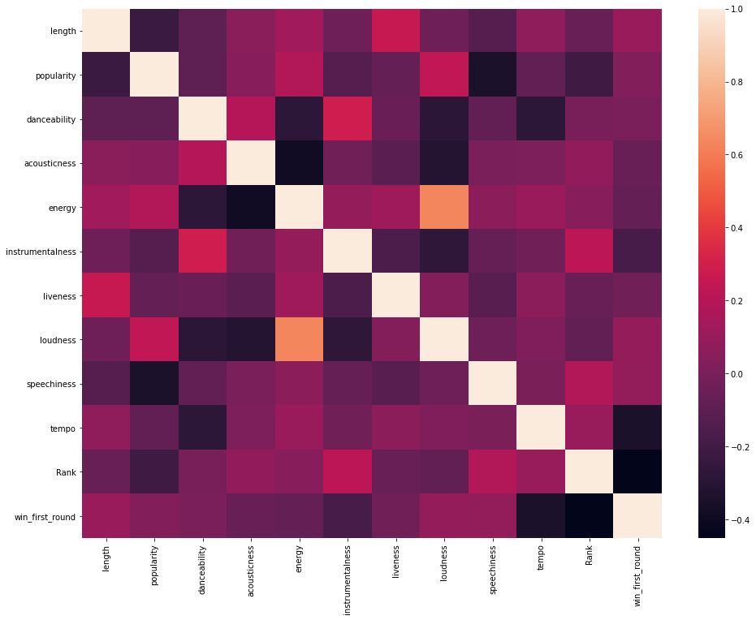

```python
corrMatrix= Train_DF.corr()
plt.figure(figsize = (16,12))
ax = sns.heatmap(corrMatrix)
```

#### To finish we start by converting strings in training DF to integers, then it is necesarry to remove those values in the testing DF that cannot be converted to string ie name, album, release date, and track id

```python
Train_DF.Likes=Train_DF.Likes.astype(dtype='int64')
Train_DF.Views=Train_DF.Views.astype(dtype='int64')
Train_DF.Dislikes=Train_DF.Dislikes.astype(dtype='int64')
Train_DF.Comments=Train_DF.Comments.astype(dtype='int64')

Oct21_DF=Oct21_DF.drop(columns='album')
Oct21_DF=Oct21_DF.drop(columns='name')
Oct21_DF=Oct21_DF.drop(columns='Name')
Oct21_DF=Oct21_DF.drop(columns='artist')
Oct21_DF=Oct21_DF.drop(columns='release_date')
Oct21_DF=Oct21_DF.drop(columns='track_id')
Oct21_DF=Oct21_DF.astype(dtype='int64')
```

#### I spent about 4 total hours trying to figure out what was going wrong with this block becuase there was constantly an error in the next block. Turns out there were two columns called name, one upercase and the other lowercase. For the whole time I was only trying to drop the lowercase, which is why the below block couldnt figure out why the test data had more columns than the training data. Its always something like that. This is why the below block has a variable called Regression_try_12, I started numbering my attempts in an effort to keep track of solutions Ive tried after the first hour and a half.

#### Finally it we utilize the training date and the values of win_first_round to predict what songs will win in first round match ups for the testing data

```python
Y_train=Train_DF[['win_first_round']]
X_train=Train_DF[['length','popularity','danceability','acousticness','energy','instrumentalness','liveness','loudness','speechiness','tempo','Rank','Views','Likes','Dislikes','Comments']]
Regression_try_12 = sm.Logit(Y_train,X_train).fit()
Regression_try_12.predict(Oct21_DF)
print(Regression_try_12.summary())
```

```
Optimization terminated successfully.
         Current function value: 0.442785
         Iterations 19
                           Logit Regression Results
==============================================================================
Dep. Variable:        win_first_round   No. Observations:                   50
Model:                          Logit   Df Residuals:                       35
Method:                           MLE   Df Model:                           14
Date:                Thu, 09 Dec 2021   Pseudo R-squ.:                  0.3605
Time:                        15:58:28   Log-Likelihood:                -22.139
converged:                       True   LL-Null:                       -34.617
Covariance Type:            nonrobust   LLR p-value:                   0.03500
====================================================================================
                       coef    std err          z      P>|z|      [0.025      0.975]
------------------------------------------------------------------------------------
length            2.998e-05   1.52e-05      1.977      0.048    2.61e-07    5.97e-05
popularity           0.0203      0.024      0.852      0.394      -0.026       0.067
danceability         2.0804      3.712      0.560      0.575      -5.195       9.356
acousticness        -0.9479      2.545     -0.372      0.710      -5.936       4.040
energy              -3.5638      3.810     -0.935      0.350     -11.032       3.904
instrumentalness  -860.2754   4691.678     -0.183      0.855   -1.01e+04    8335.245
liveness            -3.0203      3.879     -0.779      0.436     -10.622       4.581
loudness             0.2507      0.319      0.785      0.433      -0.375       0.877
speechiness         13.0495      7.450      1.752      0.080      -1.553      27.652
tempo               -0.0302      0.016     -1.840      0.066      -0.062       0.002
Rank                -0.2555      0.115     -2.217      0.027      -0.481      -0.030
Views            -2.122e-09   2.67e-09     -0.795      0.426   -7.35e-09    3.11e-09
Likes             1.762e-07   7.26e-07      0.243      0.808   -1.25e-06     1.6e-06
Dislikes          6.677e-06   1.36e-05      0.491      0.624      -2e-05    3.34e-05
Comments          6.697e-07      8e-06      0.084      0.933    -1.5e-05    1.64e-05
====================================================================================
```

```python
sub=pd.DataFrame()
sub['Win Probability']=Regression_try_12.predict(Oct21_DF)
sub['Opp Probability']=np.flip(Regression_try_12.predict(Oct21_DF)).tolist()
Win = []
for i in range (16):
  result= sub['Win Probability'][i] - sub['Opp Probability'][i]
  if result>0:
    Win.append(1)
  else:
    Win.append(0)
sub['Win']=Win
sub.to_csv('Ashby_round1_predicrtions.csv', index=False)
sub
```

|  | Win Probability | Opp Probability | Win |
| --- | --- | --- | --- |
| 0 | 0.951956 | 1.000000 | 0 |
| 1 | 1.000000 | 0.999831 | 1 |
| 2 | 0.916621 | 1.000000 | 0 |
| 3 | 1.000000 | 1.000000 | 1 |
| 4 | 0.685508 | 0.984594 | 0 |
| 5 | 1.000000 | 0.995858 | 1 |
| 6 | 1.000000 | 1.000000 | 0 |
| 7 | 0.570646 | 1.000000 | 0 |
| 8 | 1.000000 | 0.570646 | 1 |
| 9 | 1.000000 | 1.000000 | 1 |
| 10 | 0.995858 | 1.000000 | 0 |
| 11 | 0.984594 | 0.685508 | 1 |
| 12 | 1.000000 | 1.000000 | 0 |
| 13 | 1.000000 | 0.916621 | 1 |
| 14 | 0.999831 | 1.000000 | 0 |
| 15 | 1.000000 | 0.951956 | 1 |